# 10a_distribution_fitting_cont

[figure not shown]

In **business administration**, **distribution fitting** is used when a variable is uncertain and you want to model its possible values rather than assume a single average. After fitting a probability distribution from historical data or expert estimates, managers can run **scenario analysis** and simulations to evaluate risk.

A useful way to think about it:

> Average-based planning asks: “What will probably happen?” Distribution fitting asks: “What range of things could happen, and how likely is each outcome?”

## Common business uses of distribution fitting + scenario analysis

| Business area | Variable to fit | Possible distribution | Scenario analysis question |
| --- | --- | --- | --- |
| Sales forecasting | Monthly demand, revenue growth | Normal, lognormal, gamma | "What is the chance sales fall below target?" |
| Inventory management | Customer demand, lead time | Poisson, normal, negative binomial | "How much stock prevents shortages 95% of the time?" |
| Finance | Returns, cash flows, costs | Normal, lognormal, t-distribution | "What is the probability of a cash shortage?" |
| Project management | Task duration | Triangular, beta, lognormal | "How likely is the project to finish before deadline?" |
| Marketing | Customer lifetime value | Gamma, lognormal | "Which campaign performs best under uncertainty?" |
| HR management | Employee turnover | Binomial, survival distributions | "How many employees may leave next year?" |
| Operations | Machine failures, service times | Exponential, Weibull | "How many failures should we prepare for?" |
| Pricing | Customer willingness to pay | Normal, logistic | "How will profit change under different prices?" |

## Example 1: Sales scenario analysis

Suppose a company wants next quarter's revenue forecast.

Historical revenue:

- Mean = $10 million
- Standard deviation = $2 million

Instead of saying:

> "Revenue will be $10M"

Fit a distribution:

$$ Revenue \sim Normal(10,2) $$

Now simulate scenarios:

### Pessimistic scenario (10th percentile)

Revenue ≈ $7.4M

Actions:

- reduce spending
- delay hiring
- preserve cash

### Expected scenario (50th percentile)

Revenue ≈ $10M

Actions:

- normal operating plan

### Optimistic scenario (90th percentile)

Revenue ≈ $12.6M

Actions:

- increase production
- expand marketing

Management now prepares decisions, not just forecasts.

## Example 2: Inventory decision

Average daily demand = 500 units.

Bad approach:

> "Keep 500 units because average demand is 500."

Problem: half the days demand may exceed inventory.

Instead:

Fit demand distribution:

$$ Demand \sim Normal(500,100) $$

Ask:

> "How much inventory covers 95% of days?"

The answer may be around 665 units.

Scenario analysis:

| Scenario | Demand | Decision |
| --- | --- | --- |
| Low demand | 350 units | avoid excess inventory |
| Normal demand | 500 units | standard ordering |
| Demand spike | 700 units | safety stock needed |

## Example 3: New business investment

A company is deciding whether to open a new branch.

Uncertain variables:

- number of customers
- average purchase size
- operating cost
- growth rate

Fit distributions:

Customer visits:

$$ Customers \sim Poisson(\lambda) $$

Customer spending:

$$ Spending \sim Lognormal $$

Cost:

$$ Cost \sim Normal $$

Then run thousands of simulations:

$$ Profit = Revenue - Cost $$

Possible results:

- 20% chance of losing money
- 60% chance of moderate profit
- 20% chance of high profit

Decision makers evaluate risk before investing.

## Distribution fitting vs simple scenarios

Traditional scenario planning:

- Best case
- Expected case
- Worst case

Problem: no probabilities.

Distribution-based scenario analysis:

- Best case: 10% probability
- Expected case: 50% probability
- Worst case: 10% probability

You know **how likely each outcome is**.

In business analytics, distribution fitting is often the step before **Monte Carlo simulation**, risk analysis, forecasting, and strategic decision making. It changes management thinking from **point estimates** (“sales will be 10M”) to **probability-based decisions** (“there is a 15% chance sales drop below 8M; what is our plan?”).

If there is **no time component** (not forecasting months, years, trends, etc.), distribution fitting is still very useful. You are modeling **variation across customers, products, transactions, employees, projects, or events** at one point or over a collected sample.

Examples:

| Business problem | Fit distribution to | Scenario analysis |
| --- | --- | --- |
| Customer profitability | Profit per customer | "What % of customers lose money for us?" |
| Pricing decisions | Customer willingness to pay | "How many customers buy if price = $50?" |
| Market segmentation | Customer income/spending | "Which segment should we target?" |
| Credit risk | Probability of customer default | "How much loss happens in a bad scenario?" |
| Quality management | Defects per product batch | "What is probability defects exceed tolerance?" |
| Employee performance | Sales per salesperson | "How many employees exceed target?" |
| Customer service | Number of complaints per customer | "How many support staff are needed?" |
| Supplier analysis | Delivery error rates | "Which supplier creates high-risk outcomes?" |
| Cost analysis | Cost per project | "What is probability cost exceeds budget?" |

### Example 1 — Customer lifetime value (no time)

A company analyzes 50,000 customers.

Average customer profit:

$500

But customers are unequal:

- many customers spend little
- a few spend a lot

A lognormal distribution may fit:

$$ Customer\ Profit \sim Lognormal $$

Scenario analysis:

| Scenario | Customer value | Business action |
| --- | --- | --- |
| Bottom 20% | Low/negative profit | automate service, reduce incentives |
| Middle 60% | Normal customers | standard marketing |
| Top 20% | Very profitable | loyalty programs, VIP offers |

### Example 2 — Pricing a new product

Survey data:

"Maximum amount customer would pay"

Fit:

$$ Willingness\ to\ Pay \sim Normal(80,15) $$

Now test scenarios:

Price = $60:

- many buyers
- lower margin

Price = $100:

- fewer buyers
- higher margin

Management simulates:

$$ Profit=(Price-Cost)\times Number\ of\ Buyers $$

Choose the price with the best risk-adjusted outcome.

### Example 3 — Loan approval

A bank evaluates borrowers.

Fit distribution of possible losses:

$$ Loss \sim Gamma $$

Scenario analysis:

- normal case → expected losses
- bad case → high defaults
- extreme case → capital needed to survive

Question answered:

> "If we approve this portfolio, what is the chance losses exceed $10M?"

### Example 4 — HR compensation

Company analyzes salaries.

Fit:

$$ Salary \sim Lognormal $$

Questions:

- Are salaries fair?
- Who is unusually underpaid?
- What happens if we raise the bottom 10%?

Scenario:

Raise salaries below the 20th percentile:

- cost increase = ?
- number of employees affected = ?

### Key distinction

**Time-series forecasting:**

> "What will sales be next month?"

**Non-time distribution fitting:**

> "Given all possible customers/orders/projects, what range of outcomes should we expect?"

In business administration, many applications are actually the second type: **cross-sectional uncertainty**, not time forecasting.

### Input analysis

Input analysis in simulation refers to the process of analyzing and modeling the input parameters of a simulation model. This involves understanding the characteristics of the data that drive the simulation, such as arrival rates, service times, processing times, interarrival times, and other input variables.

The purpose of input analysis is to accurately represent the stochastic nature of the input data in the simulation model, allowing for realistic and meaningful simulation results. It involves the following key steps:

1. **Data Collection**: Gather historical data or empirical observations related to the input parameters of the simulation model. This may involve collecting data on arrival times, service times, queue lengths, demand patterns, or any other relevant variables.
2. **Data Exploration**: Analyze the collected data to understand its distributional properties, central tendency, variability, and other characteristics. This may involve summary statistics, histograms, probability plots, or other exploratory data analysis techniques.
3. **Distribution Selection**: Based on the characteristics of the data, select appropriate probability distributions to model the input parameters of the simulation. Common distributions include normal, exponential, Poisson, uniform, lognormal, Weibull, and others. The choice of distribution should reflect the underlying stochastic behavior of the data.
4. **Parameter Estimation**: Estimate the parameters of the selected distributions using statistical methods such as maximum likelihood estimation (MLE), method of moments, or least squares fitting. This involves fitting the chosen distribution to the observed data to find the best-fitting parameters.
5. **Goodness-of-Fit Assessment**: Evaluate the goodness of fit between the selected distributions and the observed data. This may involve statistical tests (e.g., Kolmogorov-Smirnov test, Chi-square test) or graphical methods (e.g., Q-Q plots, histograms) to assess how well the chosen distributions represent the data.
6. **Validation and Sensitivity Analysis**: Validate the input model by comparing simulated outputs with real-world observations or benchmark data. Perform sensitivity analysis to assess the impact of input parameter uncertainties on simulation results and identify influential factors.
7. **Documentation and Reporting**: Document the input analysis process, including data sources, distribution selection criteria, parameter estimation methods, goodness-of-fit results, and validation findings. Communicate the input assumptions, uncertainties, and limitations to stakeholders to ensure transparency and trust in the simulation results.

Input analysis plays a crucial role in simulation modeling, as it directly influences the accuracy, reliability, and validity of simulation outputs. By properly characterizing the stochastic behavior of input parameters, simulation models can provide valuable insights and support decision-making in complex systems and processes.

### Distribution fitting

Distribution fitting is a statistical method used to identify the probability distribution that best describes a given dataset. The purpose of distribution fitting is to find a mathematical model (probability distribution) that closely matches the observed data, allowing for various analyses, predictions, and inference tasks.

The process of distribution fitting typically involves the following steps:

1. **Selecting Candidate Distributions**: Choose a set of candidate probability distributions that are appropriate for the type of data being analyzed. Common distributions include normal (Gaussian), exponential, gamma, beta, Weibull, etc. The choice of distributions depends on the characteristics of the data and the assumptions about its underlying distribution.
2. **Estimating Parameters**: For each candidate distribution, estimate the parameters that define the distribution's shape, location, and scale. Parameter estimation methods vary depending on the distribution and may involve maximum likelihood estimation (MLE), method of moments, or least squares fitting.
3. **Goodness-of-Fit Assessment**: Evaluate how well each candidate distribution fits the observed data. This is typically done by comparing the observed data with the probability density function (PDF) or cumulative distribution function (CDF) of each distribution. Common goodness-of-fit tests include the Kolmogorov-Smirnov test, Anderson-Darling test, Chi-square test, and graphical methods such as Q-Q plots and histograms.
4. **Selecting the Best-Fitting Distribution**: Choose the distribution that provides the best fit to the data based on the goodness-of-fit assessment.
5. **Interpretation and Inference**: Once the best-fitting distribution is identified, it can be used for various purposes such as generating random samples, making predictions, estimating percentiles, calculating probabilities, and conducting hypothesis tests.

Distribution fitting is commonly used in fields such as finance, engineering, environmental science, reliability analysis, and quality control. It allows practitioners to gain insights into the underlying probabilistic behavior of the data and make informed decisions based on statistical modeling. However, it's essential to interpret the results of distribution fitting cautiously and consider the assumptions and limitations of the chosen distribution.

Maximum Likelihood Estimation (MLE) is a statistical method used to estimate the parameters of a probability distribution by maximizing the likelihood function. The goal of MLE is to find the parameter values that make the observed data the most likely, given the assumed probability distribution.

Let's break down the concept of MLE and its mathematical formulation:

### Likelihood Function:

The likelihood function $ L(\theta | x) $ represents the probability of observing the given data $ x $ for a given set of parameters $ \theta $ in the probability distribution. It is calculated as the joint probability density function (PDF) or probability mass function (PMF) of the observed data:

$$ L(\theta | x) = f(x_1, x_2, \ldots, x_n | \theta) $$

Where:

- $ \theta $ represents the parameters of the probability distribution.
- $ x_1, x_2, \ldots, x_n $ are the observed data points.
- $ f(\cdot) $ is the PDF or PMF of the probability distribution.

### Maximum Likelihood Estimation (MLE):

The MLE method seeks to find the values of the parameters $ \hat{\theta} $ that maximize the likelihood function $ L(\theta | x) $, given the observed data $ x $. Mathematically, it can be expressed as:

$$ \hat{\theta}_{\text{MLE}} = \arg \max_{\theta} L(\theta | x) $$

In simpler terms, MLE aims to find the parameter values that make the observed data most probable under the assumed probability distribution.

### Mathematical Steps:

1. **Define the Likelihood Function**: Start by specifying the likelihood function based on the chosen probability distribution and the observed data.
2. **Take the Logarithm**: To simplify calculations, it's common to work with the log-likelihood function $ \ell(\theta | x) $, which is the natural logarithm of the likelihood function:

   $$ \ell(\theta | x) = \log L(\theta | x) $$
3. **Maximize the Log-Likelihood**: Find the values of the parameters $ \hat{\theta} $ that maximize the log-likelihood function by taking the derivative of $ \ell(\theta | x) $ with respect to $ \theta $ and setting it equal to zero. Solve for $ \hat{\theta} $ using numerical optimization techniques if necessary.
4. **Estimate Parameters**: Once the maximum likelihood estimates $ \hat{\theta} $ are obtained, they serve as the parameter estimates for the probability distribution.

To solve for the Maximum Likelihood Estimation (MLE) of the parameter $ p $ for a Bernoulli distribution using the product form, we need to maximize the likelihood function:

$$ L(p | x) = \prod_{i=1}^{n} p^{x_i} (1 - p)^{1 - x_i} $$

Where:

- $ x_i $ are the observed outcomes, either 0 or 1, for $ i = 1, 2, \ldots, n $.
- $ p $ is the parameter of the Bernoulli distribution representing the probability of success.

Taking the logarithm of the likelihood function, we get the log-likelihood function:

$$ \ell(p | x) = \sum_{i=1}^{n} \left[ x_i \log(p) + (1 - x_i) \log(1 - p) \right] $$

To find the MLE of $ p $, we need to differentiate the log-likelihood function with respect to $ p $, set it equal to zero, and solve for $ p $:

$$ \frac{d \ell(p | x)}{dp} = \sum_{i=1}^{n} \left[ \frac{x_i}{p} - \frac{1 - x_i}{1 - p} \right] = 0 $$

Multiplying both sides by $ p(1-p) $ to clear the denominators gives:

$$ \sum_{i=1}^{n} \left[ x_i(1-p) - p(1 - x_i) \right] = 0 $$

Expanding and simplifying, we get:

$$ \sum_{i=1}^{n} \left[ x_i - p \right] = 0 $$

Now, we can isolate $ p $ by moving the summation to the other side:

$$ \sum_{i=1}^{n} x_i - np = 0 $$

Finally, solving for $ p $, we get:

$$ p = \frac{\sum_{i=1}^{n} x_i}{n} $$

This is the maximum likelihood estimate (MLE) of the parameter $ p $ for a Bernoulli distribution based on the observed data $ x_1, x_2, \ldots, x_n $. This estimate represents the sample proportion of successes in the data.

- Check: https://online.stat.psu.edu/stat415/lesson/1/1.2

### Try the following eExample:

Let's consider a simple example of estimating the mean and variance of a normal distribution using MLE. Given a set of observed data $ x_1, x_2, \ldots, x_n $, the likelihood function for a normal distribution is:

$$ L(\mu, \sigma^2 | x) = \prod_{i=1}^{n} \frac{1}{\sqrt{2\pi\sigma^2}} \exp \left( -\frac{(x_i - \mu)^2}{2\sigma^2} \right) $$

Taking the logarithm of the likelihood function yields the log-likelihood function, which can then be maximized to estimate the parameters $ \mu $ and $ \sigma^2 $.

### Conclusion:

MLE is a powerful and widely used method for estimating the parameters of probability distributions. It provides a principled approach to parameter estimation based on maximizing the likelihood of observing the given data under the assumed distribution. By finding the parameter values that maximize the likelihood function, MLE allows us to make inferences about the underlying population distribution from sample data.

### Resources

- https://marsgr6.github.io/presentations/Python3_Course_Content.html#/
- https://colab.research.google.com/drive/1WyKcgOa7ub81KFh_DGKONLoaSDfJXQ7K?usp=sharing

[figure not shown]

```python
import numpy as np
import matplotlib.pyplot as plt

def bernoulli_mle(data):
    # Convert data to numpy array for easier manipulation
    data = np.array(data)

    # Number of observations
    n = len(data)

    # Compute the number of successes (1s) in the data
    num_successes = np.sum(data)

    # Maximum Likelihood Estimation for p
    p_hat_mle = num_successes / n

    return p_hat_mle

# Example data (0: failure, 1: success)
# We have observed 5 successes out of 10 trials
# We want to calculate the MLE estimator of p
# Remember data \sim Bernoulli(p), p: probability of success
# Probability of observing the vector below:
# Prod([q, p, p, q, p, q, q, q, p, p])
# MLE: p = \sum data / len(data)
data = [0, 1, 1, 0, 1, 0, 0, 0, 1, 1]

# Perform Maximum Likelihood Estimation
p_hat_mle = bernoulli_mle(data)

print("Maximum Likelihood Estimate (MLE) for p:", p_hat_mle)
```

```
Maximum Likelihood Estimate (MLE) for p: 0.5
```

The Bernoulli PMF can be written in a concise form:

$$ f(x; p) = p^x (1 - p)^{1-x}, \quad x \in \{0, 1\}, $$ where $p$ is the probability of success $P(X=1) = p$.

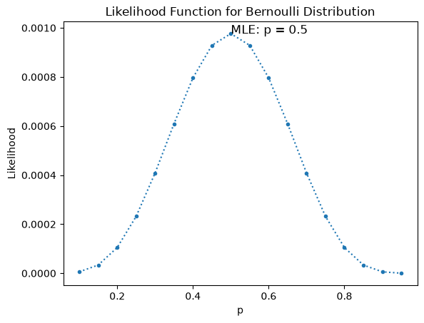

```python
def bernoulli_pmf(x, p):
    """
    Calculate the probability mass function (PMF) of a Bernoulli distribution.

    Parameters:
        x (int): Outcome (0 or 1).
        p (float): Probability of success (0 <= p <= 1).

    Returns:
        float: Probability of observing the outcome x.
    """
    if x == 1:
        return p
    elif x == 0:
        return 1 - p
    else:
        return 0  # Invalid outcome, return 0 probability

p = np.arange(0.1, 1, 0.05)

# plot likelihood function for different values of p and identify the maximum likelihood estimate
# This is grid search optimization (numerically)
# Calculate the likelihood function for different values of p of obverving the vector data
plt.plot(p, [np.prod([bernoulli_pmf(di, pi) for di in data]) for pi in p], ':.')

plt.xlabel("p")
plt.ylabel("Likelihood")
plt.title("Likelihood Function for Bernoulli Distribution")
plt.text(p_hat_mle, max([np.prod([bernoulli_pmf(di, pi) for di in data]) for pi in p]), f"MLE: p = {p_hat_mle}", fontsize=12)
plt.show()
```

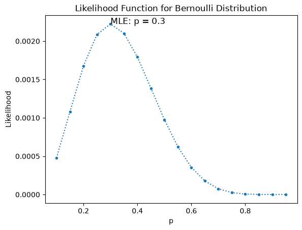

```python
data = [0, 1, 1, 0, 0, 0, 0, 0, 0, 1]
p_hat_mle = bernoulli_mle(data)

p = np.arange(0.1, 1, 0.05)

# plot likelihood function for different values of p and identify the maximum likelihood estimate
# This is grid search optimization (numerically)
# Calculate the likelihood function for different values of p of obverving the vector data
plt.plot(p, [np.prod([bernoulli_pmf(di, pi) for di in data]) for pi in p], ':.')

plt.xlabel("p")
plt.ylabel("Likelihood")
plt.title("Likelihood Function for Bernoulli Distribution")
plt.text(p_hat_mle, max([np.prod([bernoulli_pmf(di, pi) for di in data]) for pi in p]), f"MLE: p = {p_hat_mle}", fontsize=12)
plt.show()
```

```python
import pandas as pd
import seaborn as sns

# También puede leer el archivo desde el repositorio de GitHub.
data = pd.read_csv("https://raw.githubusercontent.com/marsgr6/EN-online/8a1cee296279c274d8f05f3905fce97c1f7636a2/data/CHR_data.csv")
data.head()
```

|  | Age | Attrition | BusinessTravel | DailyRate | Department | DistanceFromHome | Education | EducationField | EmployeeCount | EmployeeNumber | ... | RelationshipSatisfaction | StandardHours | StockOptionLevel | TotalWorkingYears | TrainingTimesLastYear | WorkLifeBalance | YearsAtCompany | YearsInCurrentRole | YearsSinceLastPromotion | YearsWithCurrManager |
| --- | --- | --- | --- | --- | --- | --- | --- | --- | --- | --- | --- | --- | --- | --- | --- | --- | --- | --- | --- | --- | --- |
| 0 | 41 | Yes | Travel_Rarely | 1102 | Sales | 1 | 2 | Life Sciences | 1 | 1 | ... | 1 | 80 | 0 | 8 | 0 | 1 | 6 | 4 | 0 | 5 |
| 1 | 49 | No | Travel_Frequently | 279 | Research & Development | 8 | 1 | Life Sciences | 1 | 2 | ... | 4 | 80 | 1 | 10 | 3 | 3 | 10 | 7 | 1 | 7 |
| 2 | 37 | Yes | Travel_Rarely | 1373 | Research & Development | 2 | 2 | Other | 1 | 4 | ... | 2 | 80 | 0 | 7 | 3 | 3 | 0 | 0 | 0 | 0 |
| 3 | 33 | No | Travel_Frequently | 1392 | Research & Development | 3 | 4 | Life Sciences | 1 | 5 | ... | 3 | 80 | 0 | 8 | 3 | 3 | 8 | 7 | 3 | 0 |
| 4 | 27 | No | Travel_Rarely | 591 | Research & Development | 2 | 1 | Medical | 1 | 7 | ... | 4 | 80 | 1 | 6 | 3 | 3 | 2 | 2 | 2 | 2 |

5 rows × 35 columns

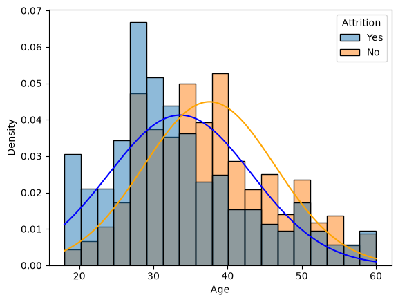

```python
# prompt: build a kde for data.Age grouped by Attrition use common normalization as false fill true

# Assume a normal distribution
from scipy.stats import norm

data_attrited = data[data["Attrition"] == "Yes"]
data_not_attrited = data[data["Attrition"] == "No"]

# MLE for mu, X \sim N(mu, sigma)
mu_yes = data_attrited.Age.mean()
mu_no = data_not_attrited.Age.mean()
sigma_yes = data_attrited.Age.std(ddof=0)  # ddof = 0, divided by n - ddof
sigma_no = data_not_attrited.Age.std(ddof=0)  # ddof = 0, divided by n - ddof
#sns.kdeplot(data=data, x="Age", hue="Attrition", common_norm=False, fill=True, cut=0)
sns.histplot(data=data, x="Age", hue="Attrition", common_norm=False, fill=True, stat="density")

x = np.linspace(data.Age.min(), data.Age.max(), 200)

plt.plot(x, norm.pdf(x, loc=mu_yes, scale=sigma_yes), color="blue")
plt.plot(x, norm.pdf(x, loc=mu_no, scale=sigma_no), color="orange")
```

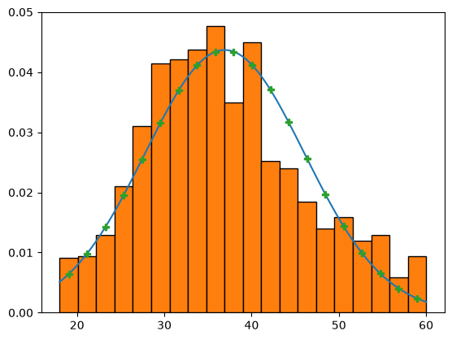

```python
plt.plot(x, norm.pdf(x, data.Age.mean(), data.Age.std(ddof=0)))
xc = plt.hist(data.Age, edgecolor='k', density=True, bins=20)[1]
xc = (xc[:-1] + xc[1:])/2
plt.plot(xc, norm.pdf(xc, data.Age.mean(), data.Age.std(ddof=0)), 'P')
```

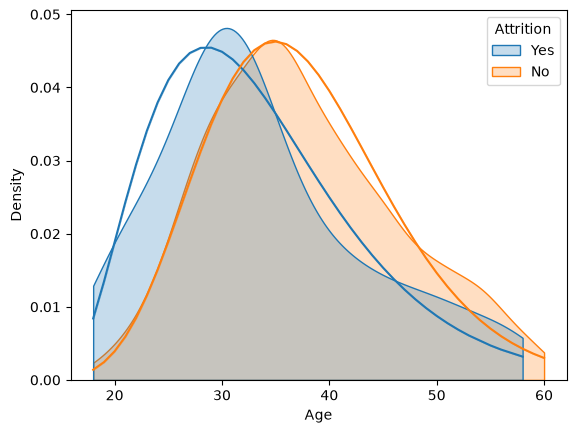

```python
# prompt: perform distribution fitting using scipy stats gamma fit for data.Age build two fits grouped for attrition groups

import scipy.stats as stats

# Fit a gamma distribution to the data for each attrition group.
data_attrited = data[data["Attrition"] == "Yes"]
data_not_attrited = data[data["Attrition"] == "No"]

# Fit the gamma distribution to the data.
fit_attrited = stats.gamma.fit(data_attrited["Age"])
fit_not_attrited = stats.gamma.fit(data_not_attrited["Age"])

# Plot the fitted distributions.
sns.kdeplot(data=data, x="Age", hue="Attrition", common_norm=False, fill=True, cut=0)
sns.lineplot(x=data_attrited["Age"], y=stats.gamma.pdf(data_attrited["Age"], *fit_attrited))
sns.lineplot(x=data_not_attrited["Age"], y=stats.gamma.pdf(data_not_attrited["Age"], *fit_not_attrited))
```

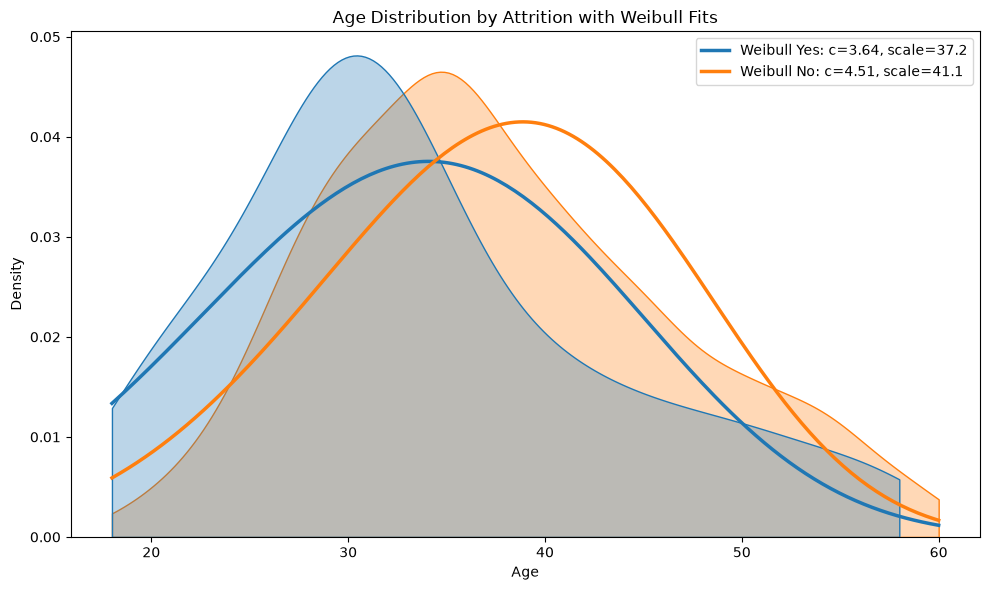

```
Fitted parameters:
Attrition=Yes: shape c=3.644, loc=0.0, scale=37.23
Attrition=No: shape c=4.513, loc=0.0, scale=41.09
```

```python
import pandas as pd
import numpy as np
import seaborn as sns
import matplotlib.pyplot as plt
from scipy import stats

data = pd.read_csv("https://raw.githubusercontent.com/marsgr6/EN-online/8a1cee296279c274d8f05f3905fce97c1f7636a2/data/CHR_data.csv")

fig, ax = plt.subplots(figsize=(10, 6))

# Plot KDEs first for reference
sns.kdeplot(data=data, x="Age", hue="Attrition", common_norm=False,
            fill=True, alpha=0.3, ax=ax, cut=0)

# Fit + plot Weibull for each group
colors = {'Yes': 'C0', 'No': 'C1'}
x_range = np.linspace(data['Age'].min(), data['Age'].max(), 200)

for attr_val in ['Yes', 'No']:
    ages = data.loc[data["Attrition"] == attr_val, "Age"]

    # Fit Weibull. floc=0 forces location=0 so distribution starts at 0, not min(Age)
    # This is usually what you want for Age. Otherwise it fits loc~18 and c<1 -> blowup
    c, loc, scale = stats.weibull_min.fit(ages, floc=0)

    # Compute PDF on smooth x range, not raw data
    pdf = stats.weibull_min.pdf(x_range, c, loc, scale)

    ax.plot(x_range, pdf, lw=2.5, color=colors[attr_val],
            label=f'Weibull {attr_val}: c={c:.2f}, scale={scale:.1f}')

ax.set_xlabel('Age')
ax.set_ylabel('Density')
ax.set_title('Age Distribution by Attrition with Weibull Fits')
ax.legend()
plt.tight_layout()
plt.show()

# Print fitted params
print("Fitted parameters:")
for attr_val in ['Yes', 'No']:
    ages = data.loc[data["Attrition"] == attr_val, "Age"]
    c, loc, scale = stats.weibull_min.fit(ages, floc=0)
    print(f"Attrition={attr_val}: shape c={c:.3f}, loc={loc:.1f}, scale={scale:.2f}")
```

# Prueba de Hipótesis Kolmogorov-Smirnov

Dada una muestra de datos $X_1, X_2, \ldots, X_n$ y una función de distribución acumulativa teórica $F(x)$, la prueba de hipótesis de Kolmogorov-Smirnov busca evaluar si la muestra sigue la distribución teórica. Aquí está un resumen más riguroso:

1. **Hipótesis Nula ($H_0$):**
   - $H_0$: La muestra sigue la distribución teórica ($F(x)$).
2. **Hipótesis Alternativa ($H_1$):**
   - $H_1$: La muestra no sigue la distribución teórica ($F(x)$).
3. **Estadístico de Prueba ($D$):**
   - El estadístico de prueba de KS se define como la máxima diferencia vertical entre la función de distribución acumulativa empírica (ECDF) de la muestra y la función de distribución acumulativa teórica: $$ D = \sup_x |F_n(x) - F(x)| $$
4. **Nivel de Significancia ($\alpha$):**
   - Establecemos el nivel de significancia para la prueba, comúnmente $\alpha = 0.05$ o $\alpha = 0.01$.
5. **Regla de Decisión:**
   - Rechazamos $H_0$ si $D$ es mayor que el valor crítico correspondiente a $\alpha$.
6. **P-Valor:**
   - El p-valor se calcula como la probabilidad de observar un $D$ tan extremo o más bajo bajo la hipótesis nula.
7. **Interpretación:**
   - Si el p-valor es menor que $\alpha$, se rechaza $H_0$, indicando que hay evidencia suficiente para afirmar que la muestra no sigue la distribución teórica.

La prueba de Kolmogorov-Smirnov es no paramétrica y no hace suposiciones sobre la forma específica de la distribución teórica. Proporciona un enfoque riguroso para evaluar la validez de la distribución asumida para una muestra de datos.

```python
# prompt: perform a Kolmogorov–Smirnov test for data.Age grouped by attrition using gamma fitting

from scipy.stats import kstest

# Fit a gamma distribution to the data for each attrition group.
data_attrited = data[data["Attrition"] == "Yes"]
data_not_attrited = data[data["Attrition"] == "No"]

# Fit the gamma distribution to the data.
fit_attrited = stats.gamma.fit(data_attrited["Age"])
fit_not_attrited = stats.gamma.fit(data_not_attrited["Age"])

# Perform the Kolmogorov-Smirnov test.
_, pval = kstest(data_attrited["Age"], stats.gamma.cdf, args=fit_attrited)
print("p-value for the Kolmogorov-Smirnov test for the attrition group 'Yes':", pval)

_, pval = kstest(data_not_attrited["Age"], stats.gamma.cdf, args=fit_not_attrited)
print("p-value for the Kolmogorov-Smirnov test for the attrition group 'No':", pval)
```

```
p-value for the Kolmogorov-Smirnov test for the attrition group 'Yes': 0.13113231469414066
p-value for the Kolmogorov-Smirnov test for the attrition group 'No': 0.017447190506019568
```

```
p-value for the Kolmogorov-Smirnov test for the attrition group 'Yes': 0.10344368767227607
p-value for the Kolmogorov-Smirnov test for the attrition group 'No': 0.000830042586803888
```

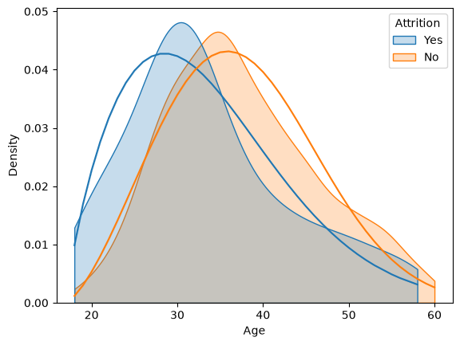

```python
# prompt: perform a Kolmogorov–Smirnov test for data.Age grouped by attrition using weibull fitting

data = pd.read_csv("https://raw.githubusercontent.com/marsgr6/EN-online/8a1cee296279c274d8f05f3905fce97c1f7636a2/data/CHR_data.csv")

# Fit a weibull distribution to the data for each attrition group.
data_attrited = data[data["Attrition"] == "Yes"]
data_not_attrited = data[data["Attrition"] == "No"]

# Fit the weibull distribution to the data.
fit_attrited = stats.weibull_min.fit(data_attrited["Age"])
fit_not_attrited = stats.weibull_min.fit(data_not_attrited["Age"])

# Plot the fitted distributions.
sns.kdeplot(data=data, x="Age", hue="Attrition", common_norm=False, fill=True, cut=0)
sns.lineplot(x=data_attrited["Age"], y=stats.weibull_min.pdf(data_attrited["Age"], *fit_attrited))
sns.lineplot(x=data_not_attrited["Age"], y=stats.weibull_min.pdf(data_not_attrited["Age"], *fit_not_attrited))

# Perform the Kolmogorov-Smirnov test.
_, pval = kstest(data_attrited["Age"], stats.weibull_min.cdf, args=fit_attrited)
print("p-value for the Kolmogorov-Smirnov test for the attrition group 'Yes':", pval)

_, pval = kstest(data_not_attrited["Age"], stats.weibull_min.cdf, args=fit_not_attrited)
print("p-value for the Kolmogorov-Smirnov test for the attrition group 'No':", pval)
```

```
p-value for the Kolmogorov-Smirnov test for the attrition group 'Yes': 0.0019750379768559948
p-value for the Kolmogorov-Smirnov test for the attrition group 'No': 1.0256677438570993e-07
```

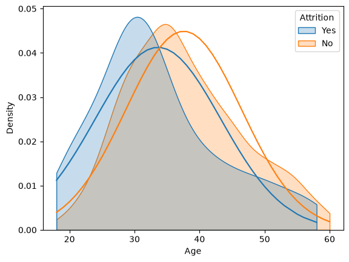

```python
# prompt: perform a Kolmogorov–Smirnov test for data.Age grouped by attrition using norm fitting

import pandas as pd
import seaborn as sns
import scipy.stats as stats
from scipy.stats import kstest

# También puede leer el archivo desde el repositorio de GitHub.
data = pd.read_csv("https://raw.githubusercontent.com/marsgr6/EN-online/8a1cee296279c274d8f05f3905fce97c1f7636a2/data/CHR_data.csv")

# Fit a normal distribution to the data for each attrition group.
data_attrited = data[data["Attrition"] == "Yes"]
data_not_attrited = data[data["Attrition"] == "No"]

# Fit the normal distribution to the data.
fit_attrited = stats.norm.fit(data_attrited["Age"])
fit_not_attrited = stats.norm.fit(data_not_attrited["Age"])

# Plot the fitted distributions.
sns.kdeplot(data=data, x="Age", hue="Attrition", common_norm=False, fill=True, cut=0)
sns.lineplot(x=data_attrited["Age"], y=stats.norm.pdf(data_attrited["Age"], *fit_attrited))
sns.lineplot(x=data_not_attrited["Age"], y=stats.norm.pdf(data_not_attrited["Age"], *fit_not_attrited))

# Perform the Kolmogorov-Smirnov test.
_, pval = kstest(data_attrited["Age"], "norm", args=fit_attrited)
print("p-value for the Kolmogorov-Smirnov test for the attrition group 'Yes':", pval)

_, pval = kstest(data_not_attrited["Age"], stats.norm.cdf, args=fit_not_attrited)
print("p-value for the Kolmogorov-Smirnov test for the attrition group 'No':", pval)
```

```python
# prompt: perform a Kolmogorov–Smirnov test for data.Age grouped by attrition using lognorm fitting

data = pd.read_csv("https://raw.githubusercontent.com/marsgr6/EN-online/8a1cee296279c274d8f05f3905fce97c1f7636a2/data/CHR_data.csv")

# Fit a lognormal distribution to the data for each attrition group.
data_attrited = data[data["Attrition"] == "Yes"]
data_not_attrited = data[data["Attrition"] == "No"]

# Fit the lognormal distribution to the data.
fit_attrited = stats.lognorm.fit(data_attrited["Age"])
fit_not_attrited = stats.lognorm.fit(data_not_attrited["Age"])

# Perform the Kolmogorov-Smirnov test.
_, pval = kstest(data_attrited["Age"], stats.lognorm.cdf, args=fit_attrited)
print("p-value for the Kolmogorov-Smirnov test for the attrition group 'Yes':", pval)

_, pval = kstest(data_not_attrited["Age"], stats.lognorm.cdf, args=fit_not_attrited)
print("p-value for the Kolmogorov-Smirnov test for the attrition group 'No':", pval)
```

```
p-value for the Kolmogorov-Smirnov test for the attrition group 'Yes': 0.23040851652326932
p-value for the Kolmogorov-Smirnov test for the attrition group 'No': 0.013638337990282407
```

# Requerimientos

```
!pip install fitter
```

|  | sumsquare_error | aic | bic | kl_div | ks_statistic | ks_pvalue |
| --- | --- | --- | --- | --- | --- | --- |
| exponnorm | 0.154338 | 1727.282271 | 1737.686451 | 11.450441 | 0.062560 | 0.299117 |
| lognorm | 0.155432 | 1723.960727 | 1734.364907 | 11.432601 | 0.066796 | 0.230409 |
| gamma | 0.155999 | 1721.487305 | 1731.891485 | 11.427316 | 0.075101 | 0.131132 |
| weibull_min | 0.156727 | 1717.530850 | 1727.935031 | 11.410502 | 0.078329 | 0.103444 |
| norm | 0.160458 | 1752.041705 | 1758.977825 | 11.412577 | 0.119990 | 0.001975 |

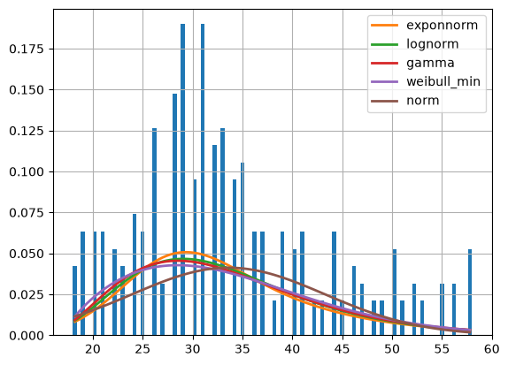

```python
from fitter import Fitter, get_common_distributions, get_distributions

f = Fitter(data_attrited["Age"],
           distributions=['gamma',
                          'lognorm',
                          "exponnorm",
                          "weibull_min",
                          "norm"])
f.fit()
f.summary()
```

```python
f.get_best(method = 'sumsquare_error')
```

```
{'exponnorm': {'K': np.float64(1.865330359903275),
  'loc': np.float64(24.57509686577498),
  'scale': np.float64(4.842286258137776)}}
```

```
p-value for the Kolmogorov-Smirnov test for the attrition group 'Yes': 0.2991170690280198
p-value for the Kolmogorov-Smirnov test for the attrition group 'No': 0.006561940367890808
```

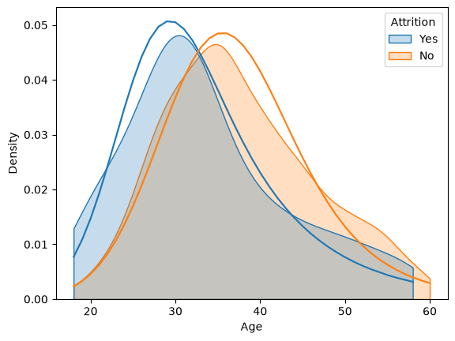

```python
# prompt: perform a Kolmogorov–Smirnov test for data.Age grouped by attrition using exponnorm fitting include graphs

import pandas as pd
import seaborn as sns
import scipy.stats as stats
from scipy.stats import kstest
from fitter import Fitter, get_common_distributions, get_distributions

# También puede leer el archivo desde el repositorio de GitHub.
data = pd.read_csv("https://raw.githubusercontent.com/marsgr6/EN-online/8a1cee296279c274d8f05f3905fce97c1f7636a2/data/CHR_data.csv")

# Fit an exponnorm distribution to the data for each attrition group.
data_attrited = data[data["Attrition"] == "Yes"]
data_not_attrited = data[data["Attrition"] == "No"]

# Fit the exponnorm distribution to the data.
fit_attrited = stats.exponnorm.fit(data_attrited["Age"])
fit_not_attrited = stats.exponnorm.fit(data_not_attrited["Age"])

# Plot the fitted distributions.
sns.kdeplot(data=data, x="Age", hue="Attrition", common_norm=False, fill=True, cut=0)
sns.lineplot(x=data_attrited["Age"], y=stats.exponnorm.pdf(data_attrited["Age"], *fit_attrited))
sns.lineplot(x=data_not_attrited["Age"], y=stats.exponnorm.pdf(data_not_attrited["Age"], *fit_not_attrited))

# Perform the Kolmogorov-Smirnov test.
_, pval = kstest(data_attrited["Age"], stats.exponnorm.cdf, args=fit_attrited)
print("p-value for the Kolmogorov-Smirnov test for the attrition group 'Yes':", pval)

_, pval = kstest(data_not_attrited["Age"], stats.exponnorm.cdf, args=fit_not_attrited)
print("p-value for the Kolmogorov-Smirnov test for the attrition group 'No':", pval)
```

|  | sumsquare_error | aic | bic | kl_div | ks_statistic | ks_pvalue |
| --- | --- | --- | --- | --- | --- | --- |
| skewnorm | 0.111453 | 8832.332372 | 8847.683988 | 10.955485 | 0.034255 | 0.108213 |
| gumbel_r | 0.111508 | 8870.003035 | 8880.237446 | 10.960417 | 0.049813 | 0.004248 |
| invweibull | 0.111508 | 8872.003042 | 8887.354659 | 10.960438 | 0.049820 | 0.004240 |
| invgauss | 0.111514 | 8841.287527 | 8856.639143 | 10.954619 | 0.035366 | 0.089357 |
| dpareto_lognorm | 0.111556 | 8850.067482 | 8880.770715 | 10.959616 | 0.035772 | 0.083191 |

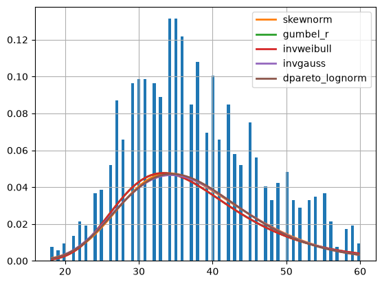

```python
from fitter import Fitter, get_common_distributions, get_distributions

f = Fitter(data_not_attrited["Age"],
           distributions=get_distributions()
)
f.fit()
f.summary()
```

```python
# best 20 distributions by ks_pvalue
f.df_errors.dropna().sort_values(by="ks_pvalue", ascending=False).head(20)
```

|  | sumsquare_error | aic | bic | kl_div | ks_statistic | ks_pvalue |
| --- | --- | --- | --- | --- | --- | --- |
| skewnorm | 0.111453 | 8832.332372 | 8847.683988 | 10.955485 | 0.034255 | 0.108213 |
| invgauss | 0.111514 | 8841.287527 | 8856.639143 | 10.954619 | 0.035366 | 0.089357 |
| dpareto_lognorm | 0.111556 | 8850.067482 | 8880.770715 | 10.959616 | 0.035772 | 0.083191 |
| genlogistic | 0.111626 | 8858.893013 | 8874.244630 | 10.964431 | 0.037322 | 0.062843 |
| ncf | 0.111628 | 8839.953167 | 8865.539194 | 10.952463 | 0.040073 | 0.037091 |
| mielke | 0.112127 | 8890.241335 | 8910.710157 | 10.973518 | 0.042029 | 0.024924 |
| burr | 0.112127 | 8890.239176 | 8910.707998 | 10.973519 | 0.042030 | 0.024923 |
| gengamma | 0.111698 | 8836.859114 | 8857.327936 | 10.951175 | 0.042284 | 0.023635 |
| f | 0.111694 | 8840.094687 | 8860.563509 | 10.951924 | 0.042472 | 0.022720 |
| fisk | 0.112237 | 8888.725732 | 8904.077349 | 10.971698 | 0.043077 | 0.019990 |
| norminvgauss | 0.111715 | 8841.313706 | 8861.782528 | 10.955390 | 0.043338 | 0.018904 |
| genhyperbolic | 0.111692 | 8840.778176 | 8866.364203 | 10.954009 | 0.043658 | 0.017645 |
| pearson3 | 0.111695 | 8836.761584 | 8852.113201 | 10.953612 | 0.043707 | 0.017456 |
| erlang | 0.111695 | 8836.761584 | 8852.113201 | 10.953610 | 0.043710 | 0.017448 |
| gamma | 0.111695 | 8836.761584 | 8852.113201 | 10.953610 | 0.043710 | 0.017447 |
| chi2 | 0.111695 | 8836.761584 | 8852.113201 | 10.953610 | 0.043710 | 0.017447 |
| recipinvgauss | 0.111717 | 8838.762782 | 8854.114398 | 10.954861 | 0.043890 | 0.016779 |
| fatiguelife | 0.111719 | 8838.799046 | 8854.150662 | 10.954878 | 0.043923 | 0.016658 |
| johnsonsu | 0.111773 | 8842.750374 | 8863.219196 | 10.956081 | 0.044551 | 0.014518 |
| nct | 0.111846 | 8849.979884 | 8870.448706 | 10.959676 | 0.044710 | 0.014016 |

```
p-value for the Kolmogorov-Smirnov test for the attrition group 'Yes': 0.23113399510151567
p-value for the Kolmogorov-Smirnov test for the attrition group 'No': 0.10821314499431556
```

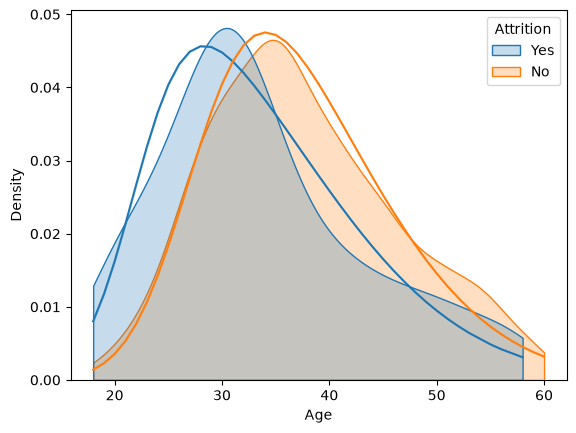

```python
# prompt: perform a Kolmogorov–Smirnov test for data.Age grouped by attrition using skewnorm fitting include graphs

import pandas as pd
import seaborn as sns
import scipy.stats as stats
from scipy.stats import kstest
from fitter import Fitter, get_common_distributions, get_distributions

# También puede leer el archivo desde el repositorio de GitHub.
data = pd.read_csv("https://raw.githubusercontent.com/marsgr6/EN-online/8a1cee296279c274d8f05f3905fce97c1f7636a2/data/CHR_data.csv")

# Fit a skewnorm distribution to the data for each attrition group.
data_attrited = data[data["Attrition"] == "Yes"]
data_not_attrited = data[data["Attrition"] == "No"]

# Fit the skewnorm distribution to the data.
fit_attrited = stats.skewnorm.fit(data_attrited["Age"])
fit_not_attrited = stats.skewnorm.fit(data_not_attrited["Age"])

# Perform the Kolmogorov-Smirnov test.
_, pval = kstest(data_attrited["Age"], stats.skewnorm.cdf, args=fit_attrited)
print("p-value for the Kolmogorov-Smirnov test for the attrition group 'Yes':", pval)

_, pval = kstest(data_not_attrited["Age"], stats.skewnorm.cdf, args=fit_not_attrited)
print("p-value for the Kolmogorov-Smirnov test for the attrition group 'No':", pval)

# Plot the fitted distributions.
sns.kdeplot(data=data, x="Age", hue="Attrition", common_norm=False, fill=True, cut=0)
sns.lineplot(x=data_attrited["Age"], y=stats.skewnorm.pdf(data_attrited["Age"], *fit_attrited))
sns.lineplot(x=data_not_attrited["Age"], y=stats.skewnorm.pdf(data_not_attrited["Age"], *fit_not_attrited))
```

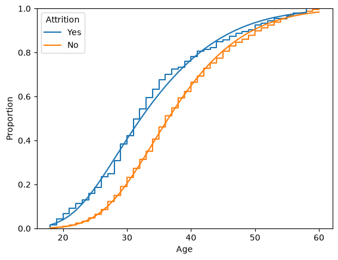

```python
# prompt: plot an empirical cdf for data.Age grouped by attrition and plot the skewnorm fitted cdf

import pandas as pd
import seaborn as sns
import scipy.stats as stats
from scipy.stats import kstest
from fitter import Fitter, get_common_distributions, get_distributions

# También puede leer el archivo desde el repositorio de GitHub.
data = pd.read_csv("https://raw.githubusercontent.com/marsgr6/EN-online/8a1cee296279c274d8f05f3905fce97c1f7636a2/data/CHR_data.csv")

# Plot an empirical CDF for data.Age grouped by attrition.
sns.ecdfplot(data=data, x="Age", hue="Attrition")

# Fit a skewnorm distribution to the data for each attrition group.
data_attrited = data[data["Attrition"] == "Yes"]
data_not_attrited = data[data["Attrition"] == "No"]

# Fit the skewnorm distribution to the data.
fit_attrited = stats.skewnorm.fit(data_attrited["Age"])
fit_not_attrited = stats.skewnorm.fit(data_not_attrited["Age"])

# Plot the fitted skewnorm CDFs.
sns.lineplot(x=data_attrited["Age"], y=stats.skewnorm.cdf(data_attrited["Age"], *fit_attrited))
sns.lineplot(x=data_not_attrited["Age"], y=stats.skewnorm.cdf(data_not_attrited["Age"], *fit_not_attrited))
```

# Construcción de un "Quantile-Quantile" (QQ) plot envelope por simulación

Implica generar datos simulados de la distribución teórica asumida y calcular los cuantiles teóricos esperados. Luego, se repite este proceso muchas veces para obtener una estimación de la variabilidad en los cuantiles observados. Aquí te presento los pasos generales:

1. **Selección de Distribución Teórica:**
   - Elige la distribución teórica con la que deseas comparar tus datos observados.
2. **Generación de Datos Simulados:**
   - Genera un gran número de conjuntos de datos simulados desde la distribución teórica seleccionada. La cantidad de conjuntos debe ser suficientemente grande para obtener una estimación robusta.
3. **Cálculo de Cuantiles Teóricos:**
   - Calcula los cuantiles teóricos correspondientes a diferentes niveles de probabilidad para la distribución teórica seleccionada.
4. **Construcción del QQ Plot para Cada Conjunto Simulado:**
   - Para cada conjunto de datos simulados, ordena los datos de manera ascendente y calcula los cuantiles observados. Luego, construye un QQ plot para ese conjunto específico.
5. **Acumulación de Cuantiles Observados:**
   - Acumula los cuantiles observados para cada conjunto simulado.
6. **Cálculo de Cuantiles del Envelope:**
   - Para cada nivel de probabilidad, calcula los cuantiles que definen el envelope utilizando, por ejemplo, percentiles específicos de la distribución acumulada de los cuantiles acumulados.
7. **Construcción del QQ Plot con Envelope:**
   - Representa gráficamente los cuantiles acumulados observados junto con el envelope calculado alrededor de la línea de igualdad.
8. **Interpretación:**
   - Evalúa visualmente si la mayoría de los puntos del QQ plot están dentro del envelope. Si la mayoría lo está, sugiere que los datos observados son consistentes con la distribución teórica seleccionada.
9. **Análisis de la Simulación:**
   - Analiza la variabilidad en la posición de los cuantiles observados para obtener información sobre la incertidumbre en el ajuste.

Este enfoque de simulación proporciona una manera robusta de construir un QQ plot envelope, permitiendo una evaluación más completa de la incertidumbre asociada con la comparación entre los datos observados y la distribución teórica asumida. La variabilidad en los cuantiles observados reflejará la variabilidad inherente en los datos y ayudará en la interpretación del ajuste de la distribución.

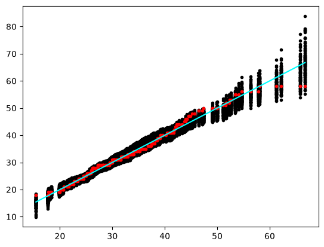

```python
x_ref = np.sort(stats.skewnorm.rvs(*fit_attrited, size=len(data_attrited)))  # This is equivalent to the ECDF
for i in range(100):  # create 100 samples from the hypothesized distribution
    x_rvs = np.sort(stats.skewnorm.rvs(*fit_attrited, size=len(data_attrited)))  # This is equivalent to the ECDF
    plt.plot(x_ref, x_rvs, '.k')  # Q-Q plot
plt.plot(x_ref, np.sort(data_attrited["Age"]), '.r') # Q-Q plot
plt.plot(x_ref, x_ref, 'cyan')  # line y = x
```

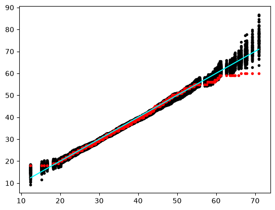

```python
x_ref = np.sort(stats.skewnorm.rvs(*fit_not_attrited, size=len(data_not_attrited)))  # This is equivalent to the ECDF
for i in range(100):  # create 100 samples from the hypothesized distribution
    x_rvs = np.sort(stats.skewnorm.rvs(*fit_not_attrited, size=len(data_not_attrited)))  # This is equivalent to the ECDF
    plt.plot(x_ref, x_rvs, '.k')  # Q-Q plot
plt.plot(x_ref, np.sort(data_not_attrited["Age"]), '.r') # Q-Q plot
plt.plot(x_ref, x_ref, 'cyan')  # line y = x
```

https://medium.com/the-researchers-guide/finding-the-best-distribution-that-fits-your-data-using-pythons-fitter-library-319a5a0972e9

[figure not shown]

Created in Deepnote